# Visualisation and statistical analysis

Michael Dunn, Dept. of Linguistics and Philology, Uppsala University

Session 4, 2018-10-18

Main issues for today

- wide vs long data
- fixing data type: as.numeric, as.character
- readxl package
- rbind
- testthat package
- gather and spread

# Some homework revision

```r
library(tidyverse)
library(babynames)
```

Kelly visualisation:

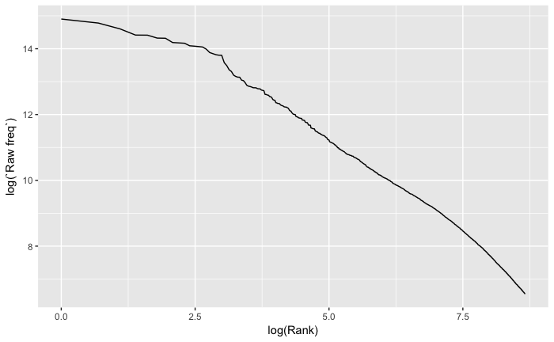

```r
read_tsv("./Swedish-Kelly_M3_CEFR.tsv") %>%
  arrange(desc(`Raw freq`)) %>%
  filter(!is.na(`Raw freq`)) %>%
  filter(WPM != 1000000) %>%
  mutate(Rank=1:length(ID)) %>%
  ggplot(aes(x=log(Rank), y=log(`Raw freq`))) + geom_line()
```

Another version of the same thing, less “idiomatic” tidyverse (old-fashioned way)

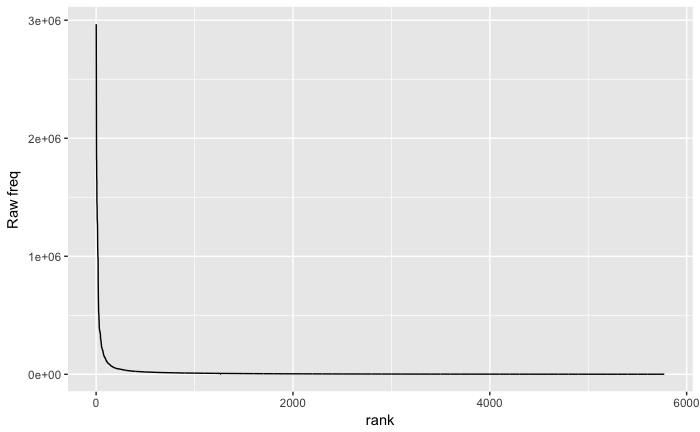

```r
kelly <- read_tsv("Swedish-Kelly_M3_CEFR.tsv")
kelly <- filter(kelly, !(is.na(`Raw freq`) | WPM == 1000000))
kelly$rank <- 1:nrow(kelly)
kelly %>% ggplot(aes(rank, `Raw freq`)) + geom_line()
```

Now plot this again taking the log values of rank and frequency

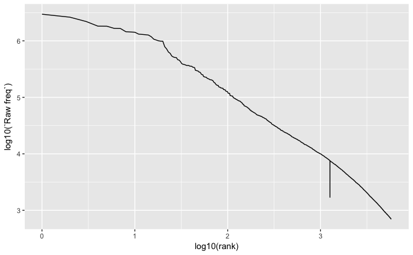

```r
read_tsv("Swedish-Kelly_M3_CEFR.tsv") %>%
  filter(!(is.na(`Raw freq`) | WPM == 1000000)) %>%
  mutate(rank=1:nrow(.)) %>%
  ggplot(aes(log10(rank), log10(`Raw freq`))) + geom_line()
```

What’s that “blip”? How can we fix it?

```r
# Sort it by Raw freq, descending
kelly %>% arrange(desc(`Raw freq`))
```

| ID | Raw freq | WPM | CEFR levels | Source | Grammar | Swedish items for translation | Word classes | Examples | rank |
| --- | --- | --- | --- | --- | --- | --- | --- | --- | --- |
| 87 | 2966316 | 26019.68 | A1 | SweWaC | NA | och (vardagl. å; förk. o.) | conj | NA | 1 |
| 88 | 2624032 | 23017.26 | A1 | SweWaC | att | vara (vardagl. va) | verb | e.g. var så god! | 2 |
| 89 | 2197163 | 19272.89 | A1 | SweWaC | NA | i | prep | NA | 3 |
| 90 | 1822142 | 15983.31 | A1 | SweWaC | att | ha | verb | NA | 4 |
| 91 | 1816701 | 15935.58 | A1 | SweWaC | NA | dess | pronoun | NA | 5 |
| 92 | 1662413 | 14582.21 | A1 | SweWaC | NA | det | pronoun | NA | 6 |
| 93 | 1654320 | 14511.22 | A1 | SweWaC | NA | en | det | NA | 7 |
| 94 | 1451792 | 12734.70 | A1 | SweWaC | NA | som | pronoun | NA | 8 |
| 95 | 1435426 | 12591.15 | A1 | SweWaC | NA | på | prep | NA | 9 |
| 96 | 1420786 | 12462.73 | A1 | SweWaC | NA | å | prep | e.g. å ena sidan…å andra sidan | 10 |

[output cut: 990 more lines]

And then redo everything with the fix incorporated

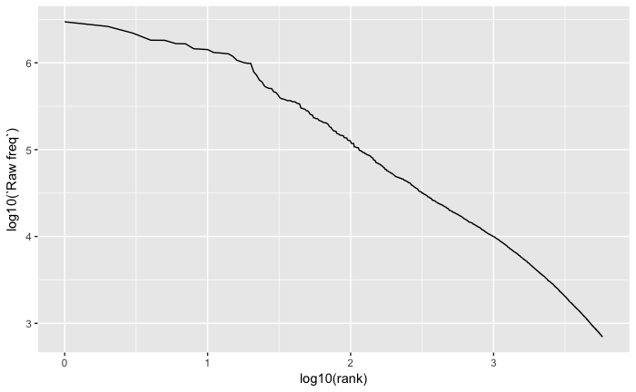

```r
read_tsv("Swedish-Kelly_M3_CEFR.tsv") %>%
  arrange(desc(`Raw freq`)) %>%
  filter(!(is.na(`Raw freq`) | WPM == 1000000)) %>%
  mutate(rank=1:nrow(.)) %>%
  ggplot(aes(log10(rank), log10(`Raw freq`))) + geom_line()
```

# Wide and long data

Wide data:

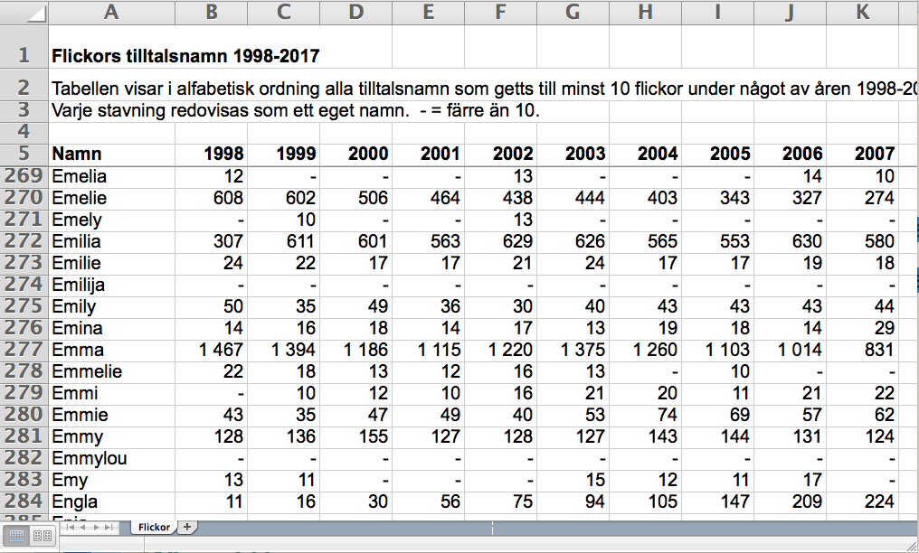

Long data:

```r
head(babynames)
```

| year | sex | name | n | prop |
| --- | --- | --- | --- | --- |
| 1880 | F | Mary | 7065 | 0.07238 |
| 1880 | F | Anna | 2604 | 0.02668 |
| 1880 | F | Emma | 2003 | 0.02052 |
| 1880 | F | Elizabeth | 1939 | 0.01987 |
| 1880 | F | Minnie | 1746 | 0.01789 |
| 1880 | F | Margaret | 1578 | 0.01617 |

- Long data is good for visual analysis: every row is an observation
- Humans generally prefer to *read* wide data
- There are times when wide data is important
- `gather` changes wide to long
- `spread` changes long to wide

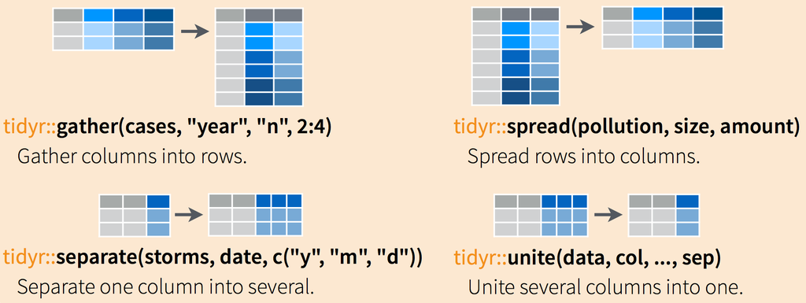

Wide vs. long

Wide format

```r
data <- tibble(row=c("A", "B"), x=1:2, y=3:4, z=5:6)
data
```

| row | x | y | z |
| --- | --- | --- | --- |
| A | 1 | 3 | 5 |
| B | 2 | 4 | 6 |

Long format

```r
data %>% gather("column", "value", c("x", "y", "z"))
```

| row | column | value |
| --- | --- | --- |
| A | x | 1 |
| B | x | 2 |
| A | y | 3 |
| B | y | 4 |
| A | z | 5 |
| B | z | 6 |

# Loading data directly from excel format

(this is relatively new, I didn’t know about it earlier)

These excel files are from the Swedish [Central Statistics Agency, SCB](http://www.scb.se/hitta-statistik/statistik-efter-amne/befolkning/amnesovergripande-statistik/namnstatistik/)

Look at the spreadsheet and the read_excel documentation - named sheets (we need to select a particular sheet) - blank lines at beginning (`skip` them) - column types (can you see what they are?)

```r
library(readxl)
girls <- read_excel("be0001namntab11_2017.xlsx", sheet = "Flickor", skip = 4)
boys <- read_excel("be0001namntab12_2017.xlsx", sheet = "Pojkar", skip = 4)
head(girls)
```

| Namn | 1998 | 1999 | 2000 | 2001 | 2002 | 2003 | 2004 | 2005 | 2006 | 2007 | 2008 | 2009 | 2010 | 2011 | 2012 | 2013 | 2014 | 2015 | 2016 | 2017 |
| --- | --- | --- | --- | --- | --- | --- | --- | --- | --- | --- | --- | --- | --- | --- | --- | --- | --- | --- | --- | --- |
| Aaliyah | - | - | - | - | - | - | - | - | - | - | - | - | - | - | 17 | 14 | - | 14 | 10 | 26 |
| Abigail | - | - | - | - | - | - | - | - | - | - | 10 | - | 13 | 15 | 18 | 13 | 17 | 20 | 21 | 27 |
| Ada | - | - | - | 14 | - | 12 | 12 | 14 | 14 | 12 | 14 | 21 | 25 | 22 | 23 | 24 | 29 | 28 | 38 | 41 |
| Adela | - | - | 10 | - | - | 12 | - | - | 12 | 13 | - | - | 13 | - | 15 | 10 | - | 17 | 11 | 13 |
| Adele | - | - | - | - | - | - | - | - | - | - | 10 | - | - | 14 | 44 | 54 | 89 | 92 | 124 | 103 |
| Adéle | - | - | - | - | - | - | - | - | - | - | - | - | - | - | - | - | 11 | - | - | - |

Check the column titles:

```r
names(girls)
```

```
 [1] "Namn" "1998" "1999" "2000" "2001" "2002" "2003" "2004" "2005" "2006" "2007" "2008" "2009" "2010" "2011" "2012" "2013"
[18] "2014" "2015" "2016" "2017"
```

```r
names(boys)
```

```
 [1] "Namn" "1998" "1999" "2000" "2001" "2002" "2003" "2004" "2005" "2006" "2007" "2008" "2009" "2010" "2011" "2012" "2013"
[18] "2014" "2015" "2016" "2017"
```

We want to check that the column names of `girls` and `boys` are the same. You can just do one of the following:

```r
names(girls) == names(boys) # expect a long vector of TRUEs
```

```
 [1] TRUE TRUE TRUE TRUE TRUE TRUE TRUE TRUE TRUE TRUE TRUE TRUE TRUE TRUE TRUE TRUE TRUE TRUE TRUE TRUE TRUE
```

You can also do:

```r
all(names(girls) == names(boys)) # returns TRUE if all the values in the vector are TRUE
```

```
[1] TRUE
```

But a more elegant way to do it is to incorporate *tests*. The `testthat` package introduces a bunch of `expect_` functions that make your script crash (infomatively!) if the expectation is violated.

```r
library(testthat)
expect_equal(names(girls), names(boys))
```

The test does *nothing* if it passes. You can incorporate tests into your scripts to make sure nothing unexpected is happening after e.g. you update data.

```r
a <- 1:5
b <- 1:4
expect_equal(a, b)
```

```
Error: `a` not equal to `b`.
Lengths differ: 5 is not 4
```

Assuming things work as expected you can add a column to specify male or female name, and then bind your tables together into a single table.

```r
library(tidyverse)
girls <- girls %>% mutate(sex = "F")
boys <- boys %>% mutate(sex = "M")
data <- rbind(girls, boys)
```

Now take a look:

```r
head(data)
```

| Namn | 1998 | 1999 | 2000 | 2001 | 2002 | 2003 | 2004 | 2005 | 2006 | 2007 | 2008 | 2009 | 2010 | 2011 | 2012 | 2013 | 2014 | 2015 | 2016 | 2017 | sex |
| --- | --- | --- | --- | --- | --- | --- | --- | --- | --- | --- | --- | --- | --- | --- | --- | --- | --- | --- | --- | --- | --- |
| Aaliyah | - | - | - | - | - | - | - | - | - | - | - | - | - | - | 17 | 14 | - | 14 | 10 | 26 | F |
| Abigail | - | - | - | - | - | - | - | - | - | - | 10 | - | 13 | 15 | 18 | 13 | 17 | 20 | 21 | 27 | F |
| Ada | - | - | - | 14 | - | 12 | 12 | 14 | 14 | 12 | 14 | 21 | 25 | 22 | 23 | 24 | 29 | 28 | 38 | 41 | F |
| Adela | - | - | 10 | - | - | 12 | - | - | 12 | 13 | - | - | 13 | - | 15 | 10 | - | 17 | 11 | 13 | F |
| Adele | - | - | - | - | - | - | - | - | - | - | 10 | - | - | 14 | 44 | 54 | 89 | 92 | 124 | 103 | F |
| Adéle | - | - | - | - | - | - | - | - | - | - | - | - | - | - | - | - | 11 | - | - | - | F |

# Convert swedish babynames from wide to long

Back to Swedish baby names. In order to work with this we need to convert it from wide to long format: there should be a single `year` column with year column headers as variables.

# Gathering

**This is very important!**

- gather(.data, new_column_with_collected_headers, new_column_for_values_of_cells, …all_the_columns_to_gather…)

The following function all the year columns into one column with year (the old column header), and one column with the value of the cell.

We use `as.character` because this refers to the column headers, which count as text. If we used numerals what would it mean?

```r
long.data <- gather(data, year, count, as.character(1998:2017))
head(long.data)
```

| Namn | sex | year | count |
| --- | --- | --- | --- |
| Aaliyah | F | 1998 | - |
| Abigail | F | 1998 | - |
| Ada | F | 1998 | - |
| Adela | F | 1998 | - |
| Adele | F | 1998 | - |
| Adéle | F | 1998 | - |

Note that the year and count columns are shown as (character) rather than (a numeric type). You won’t be able to graph these until you fix them. The count data is character rather than numeric; fix this with mutate

```r
long.data <- gather(data, year, count, as.character(1998:2017)) %>%
  mutate(year=as.numeric(year), count=as.numeric(count))
```

```
NAs introduced by coercionWarning messages:
1: Unknown or uninitialised column: 'F'.
2: Unknown or uninitialised column: 'M'.
```

```r
head(long.data)
```

| Namn | sex | year | count |
| --- | --- | --- | --- |
| Aaliyah | F | 1998 | NA |
| Abigail | F | 1998 | NA |
| Ada | F | 1998 | NA |
| Adela | F | 1998 | NA |
| Adele | F | 1998 | NA |
| Adéle | F | 1998 | NA |

Now ggplot recognises the numbers as numeric rather than as character strings it can plot them:

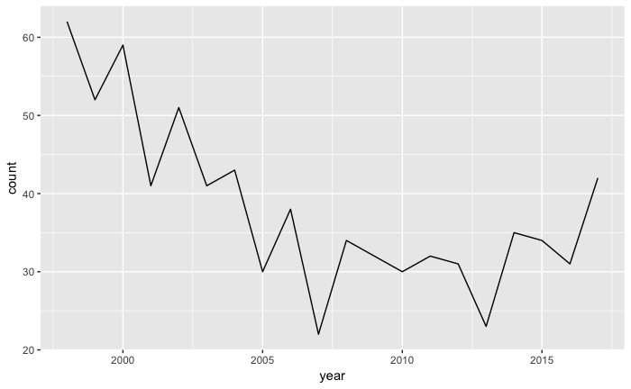

```r
long.data %>% filter(Namn=="Michael") %>% ggplot(aes(x=year, y=count)) + geom_line()
```

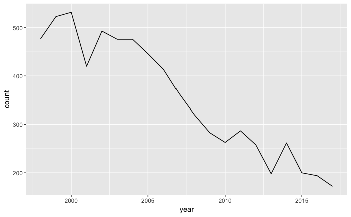

```r
long.data %>% filter(Namn=="Linnéa") %>% ggplot(aes(x=year, y=count)) + geom_line()
```

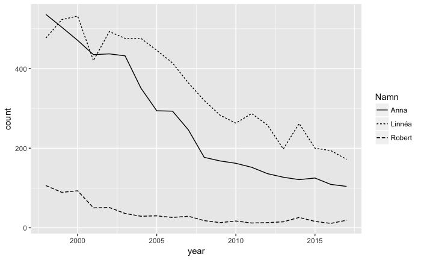

```r
long.data %>% filter(Namn=="Linnéa" | Namn=="Anna" | Namn=="Robert") %>% ggplot(aes(x=year, y=count, linetype=Namn)) + geom_line()
```

# Fixing (“coercing”) character types

Look again at `head(data)`. All the numbers have been imported at characters. Can you guess why?

This is a problem:

```r
values <- c("1", "7", "8?", "-", "not applicable")
values
```

```
[1] "1"              "7"              "8?"             "-"              "not applicable"
```

```r
# You can't do mathematical operations with the character representations of numbers
# values + 1
```

Use `as.numeric` to coerce the type of an object to numeric. Anything that can’t be coerced turns into NA (not available)

```r
numeric.values <- as.numeric(values)
```

```
NAs introduced by coercion
```

```r
numeric.values # note NA for "not available"; the warning message
```

```
[1]  1  7 NA NA NA
```

```r
numeric.values + 1
```

```
[1]  2  8 NA NA NA
```

You can do this the other way around too, with `as.character` (like we did in the gather example above)

There are other `as.XXX` functions for every other type of object, but you’re less likely to need these.

### summarise() and group_by()

Reduces all the rows to *one* row

```r
babynames %>% summarise(mean_n=mean(n), median_n=median(n))
```

| mean_n | median_n |
| --- | --- |
| 183.4 | 12 |

`group_by` reduces all the rows to a smaller number of rows, according to the `group_by` term/s; summarise then works on each *group* (`group_by` doesn’t make much sense without a `summarise` or similar after it)

```r
# group_by sex
babynames %>% filter(name=="Michael") %>% group_by(sex) %>% summarise(first_seen=min(year), last_seen=max(year))
```

| sex | first_seen | last_seen |
| --- | --- | --- |
| F | 1897 | 2015 |
| M | 1880 | 2015 |

```r
our_names = c("Anna", "Bror-Magnus", "Lena", "Linnéa", "Maja", "Marc", "Mervi", "Rima", "Robert", "Rune", "Michael")
babynames %>% filter(name %in% our_names) %>% group_by(name) %>% summarise(total=sum(n))
```

| name | total |
| --- | --- |
| Anna | 881714 |
| Lena | 135184 |
| Maja | 1591 |
| Marc | 138842 |
| Michael | 4345569 |
| Rima | 1366 |
| Robert | 4823167 |
| Rune | 257 |

Exercise: what are the mean and median number of male and female names in the data?

You can group by multiple things at once to get every combination

```r
babynames %>%
  filter(name %in% c("Michael", "Magnus", "Anna", "Maja")) %>%
  group_by(name, sex) %>% # every combination of name and sex
  summarise(total=sum(n))
```

| name | sex | total |
| --- | --- | --- |
| Anna | F | 878988 |
| Anna | M | 2726 |
| Magnus | M | 2947 |
| Maja | F | 1591 |
| Michael | F | 21641 |
| Michael | M | 4323928 |

## Spread example

Here’s a chance to use `spread`. Let’s say we want to look at the *ratio* of male to female version of each of these names:

```r
babynames %>%
  filter(name %in% c("Michael", "Magnus", "Anna", "Maja")) %>%
  group_by(name, sex) %>% # every combination of name and sex
  summarise(total=sum(n)) %>%
  spread(sex, total)
```

| name | F | M |
| --- | --- | --- |
| Anna | 878988 | 2726 |
| Magnus | NA | 2947 |
| Maja | 1591 | NA |
| Michael | 21641 | 4323928 |

We could convert this in a manliness rating for names:

```r
babynames %>%
  filter(name %in% c("Michael", "Magnus", "Anna", "Maja")) %>%
  group_by(name, sex) %>% # every combination of name and sex
  summarise(total=sum(n)) %>%
  spread(sex, total) %>%
  mutate(manliness=M/(M+F))
```

| name | F | M | manliness |
| --- | --- | --- | --- |
| Anna | 878988 | 2726 | 0.003092 |
| Magnus | NA | 2947 | NA |
| Maja | 1591 | NA | NA |
| Michael | 21641 | 4323928 | 0.995020 |

Oops, have to change the NAs to 0, because anything + NA is NA

```r
babynames %>%
  filter(name %in% c("Michael", "Magnus", "Anna", "Maja")) %>%
  group_by(name, sex) %>% # every combination of name and sex
  summarise(count=sum(n)) %>%
  spread(sex, count) -> data
# writing an intermediate variable is a clunky way to do it, but I'm not too proud
data$F[is.na(data$F)] <- 0
data$M[is.na(data$M)] <- 0
data %>%
  mutate(manliness=M/(M+F)) %>%
  arrange(desc(manliness))
```

| name | F | M | manliness |
| --- | --- | --- | --- |
| Magnus | 0 | 2947 | 1.000000 |
| Michael | 21641 | 4323928 | 0.995020 |
| Anna | 878988 | 2726 | 0.003092 |
| Maja | 1591 | 0 | 0.000000 |

## an aside on indexing

```r
values <- c(3,6,17, NA, NA, 5)
values
```

```
[1]  3  6 17 NA NA  5
```

```r
is.na(values)
```

```
[1] FALSE FALSE FALSE  TRUE  TRUE FALSE
```

Indexes in square brackets

```r
values[2]
```

```
[1] 6
```

```r
values[2:4]
```

```
[1]  6 17 NA
```

Assign to indexed vectors

```r
values[1:2] <- -99
values
```

```
[1] -99 -99  17  NA  NA   5
```

```r
values[is.na(values)] <- 0
values
```

```
[1] -99 -99  17   0   0   5
```

Other kinds of logic also possible

```r
values[values < 0 ] <- NA
values
```

```
[1] NA NA 17  0  0  5
```

### Histogram

```r
babynames %>% filter(year==2000) %>% ggplot(aes(x=log10(n))) + geom_histogram()
```

## stringr

Simple character manipulations, see documentation: https://stringr.tidyverse.org/articles/stringr.html

- Look at the cheatsheet, from https://github.com/rstudio/cheatsheets/
- The **Data transformation** and **R Markdown** cheatsheets are good too

```r
library(stringr) # you might need to load this separately (or it might be part of tidyverse)
# str_sub(x, start, stop)
our_names = c("Anna", "Bror-Magnus", "Lena", "Linnéa", "Maja", "Marc", "Mervi", "Rima", "Robert", "Rune")
str_sub(our_names, 1, 2)
# positive and negative indices
str_sub(our_names, 1, 1)
str_sub(our_names, -3, -1) %>% str_to_upper()
```

- We can do lots of interesting things with this by adding the output of this to a new column using `mutate`

Exercises:

Try one of: - add a column called `final_a` with TRUE or FALSE values for whether the name has a final *a* - add a column for `first_letter` - explore this variable (e.g. interaction with sex, change over time)

# Trends in a-final names

```r
babynames %>% mutate(final_a=str_sub(name, start=-1)=="a")
```

We could e.g. graph this, with sex as a variable:

```r
babynames %>%
  mutate(final_a=str_sub(name, start=-1)=="a") %>%
  group_by(year, sex, final_a) %>%
  summarise(count=n()) %>%
  ggplot(aes(x=year, y=count, colour=sex, linetype=final_a)) + geom_line()
```

But this really only makes sense as proportions:

```r
babynames %>%
  mutate(final_a=str_sub(name, start=-1)=="a") %>%
  group_by(year, sex, final_a) %>%
  summarise(count=n()) %>%
  spread(final_a, count) %>%
  rename(no_final_a=`FALSE`, final_a=`TRUE`) %>%
  mutate(prop=final_a/(final_a+no_final_a)) %>%
  ggplot(aes(x=year, y=prop, colour=sex)) + geom_line()
```

Some ideas for further exercises

- What’s happened to “Leslie”? Plot the change in male and female Leslies over time
- Can you order names by what year they peak?
- Can you work out a way to find more names which have changed their typical gender over time?
- Has the proportion of vowel final names (consider girls and boys separately) changed over time?
- What is the male-female bias in initial letters?
- How many distinct names are used for boys and girls each year? What about a better measure (e.g. number of names/number of individuals)